# Full Shark Analysis

Alex Benecke

July 23, 2018

## Data Exploration

## QA/QC

** NOTE: I Need to change or CHECK ez,names is correct**

```r
### CARCHARHINUS.ACRONOTUS (Blacknose)

### CARCHARHINUS.LIMBATUS (Blacktip)

### CARCHARHINUS.LEUCAS (Bull)

### CARCHARHINUS.PLUMBEUS (Sandbar)

### RHIZOPRIONODON.TERRAENOVAE (Sharpnose)

### CARCHARHINUS.FALCIFORMIS (Silky)

### CARCHARHINUS.BREVIPINNA (Spinner)

### GALEOCERDO.CUVIER (Tiger)

sp.df <- list(blacknose.df = acronotus.df <- extract.taxa.df.fun(eff2,
                             eff2$CARCHARHINUS.ACRONOTUS),

              blacktip.df = extract.taxa.df.fun(eff2,
                                     eff2$CARCHARHINUS.LIMBATUS),

              bull.df = extract.taxa.df.fun(eff2,
                                     eff2$CARCHARHINUS.LEUCAS),

              sandbar.df = extract.taxa.df.fun(eff2,
                                     eff2$CARCHARHINUS.PLUMBEUS),

              sharpnose.df = extract.taxa.df.fun(eff2,
                                     eff2$RHIZOPRIONODON.TERRAENOVAE),

              silky.df = extract.taxa.df.fun(eff2,
                                     eff2$CARCHARHINUS.FALCIFORMIS),

              spinner.df = extract.taxa.df.fun(eff2,
                                    eff2$CARCHARHINUS.BREVIPINNA),

              tiger.df = extract.taxa.df.fun(eff2,
                                     eff2$GALEOCERDO.CUVIER))
```

### Scatterplots of CPE vs Explanatory variables

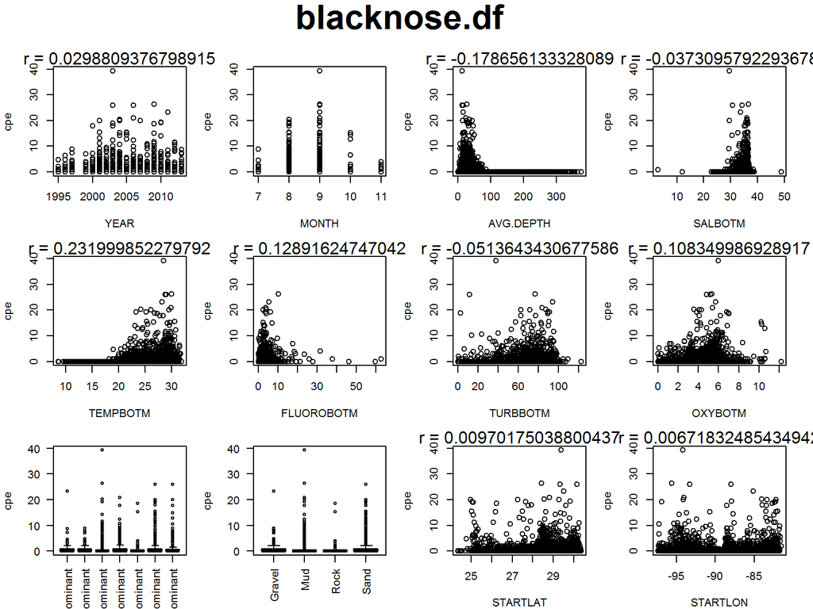

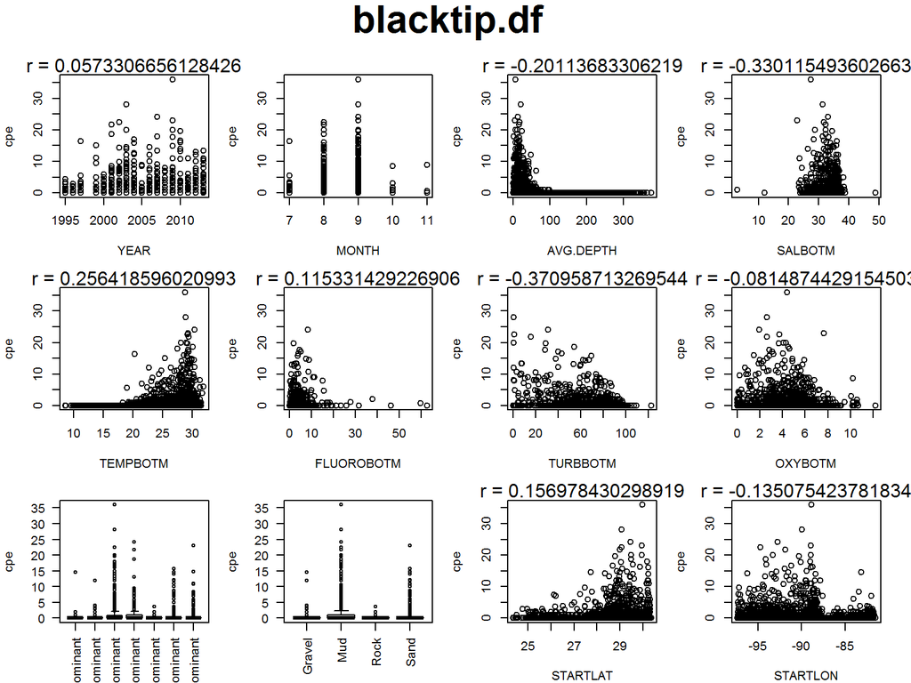

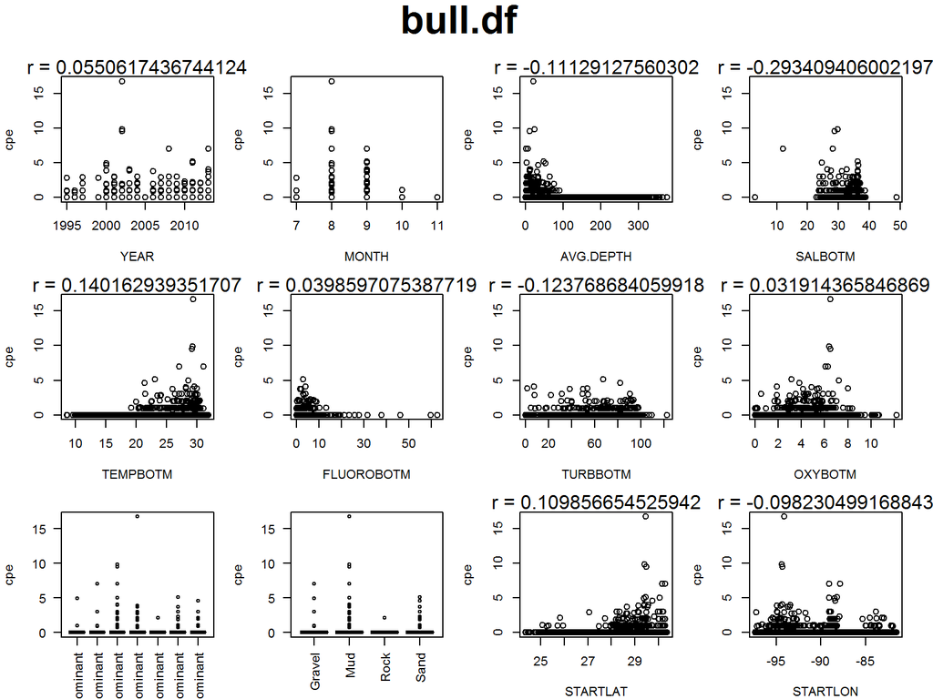

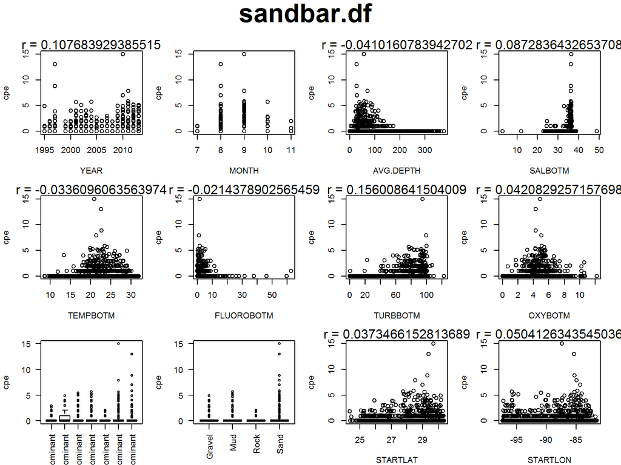

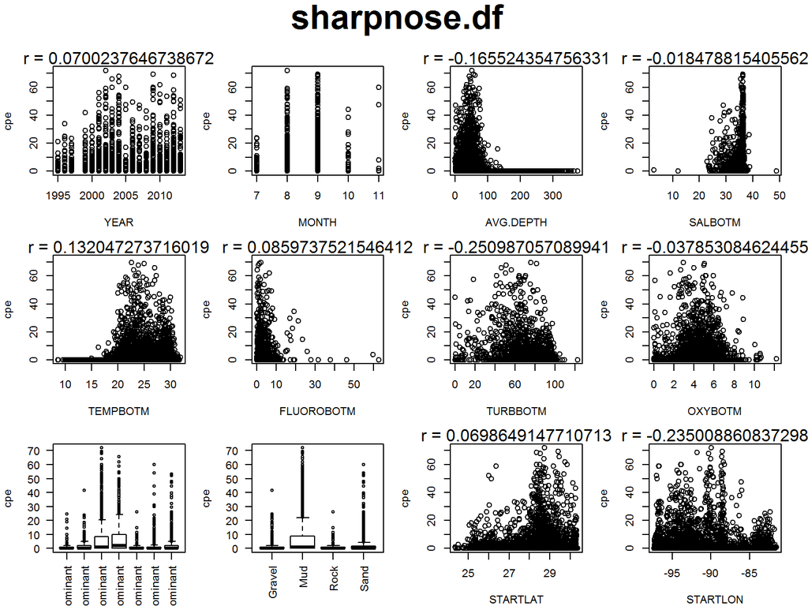

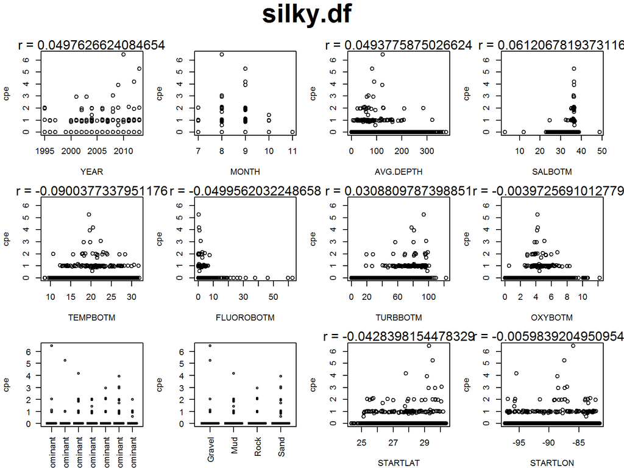

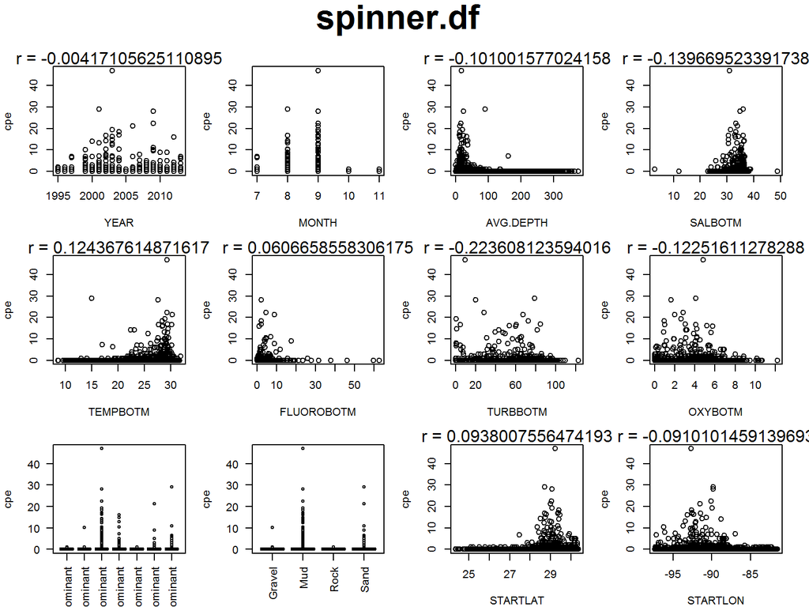

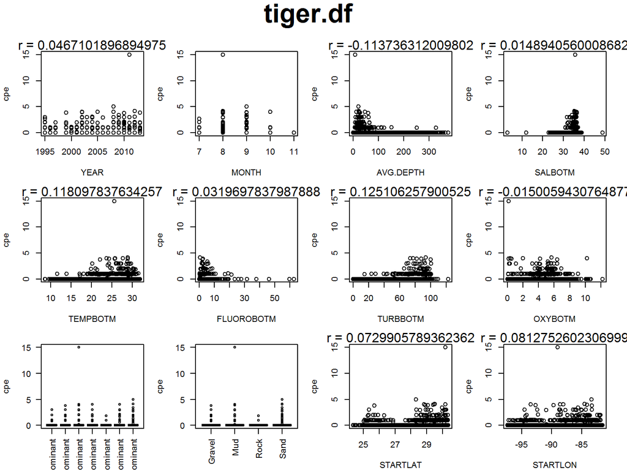

```r
scatter_fn(sp.df)
```

Looks like we have a few Outliers.

### Identify Outliers

```r
summary(eff2[c(6:8,12,38:50)])
```

```
##     STARTLAT        STARTLON        STARTDEPTH        ENDDEPTH
##  Min.   :24.36   Min.   :-97.34   Min.   :  1.50   Min.   :  1.50
##  1st Qu.:27.72   1st Qu.:-92.90   1st Qu.: 23.10   1st Qu.: 23.28
##  Median :28.57   Median :-88.37   Median : 41.51   Median : 41.51
##  Mean   :28.33   Mean   :-88.87   Mean   : 66.24   Mean   : 66.29
##  3rd Qu.:29.31   3rd Qu.:-84.52   3rd Qu.: 75.35   3rd Qu.: 75.90
##  Max.   :30.36   Max.   :-81.59   Max.   :375.00   Max.   :375.00
##                                                    NA's   :1
##     TEMPBOTM       FLUOROBOTM         TURBBOTM         OXYBOTM
##  Min.   : 8.61   Min.   : 0.0000   Min.   :  0.00   Min.   : 0.000
##  1st Qu.:20.28   1st Qu.: 0.4402   1st Qu.: 63.24   1st Qu.: 3.727
##  Median :23.61   Median : 1.7146   Median : 76.93   Median : 4.500
##  Mean   :23.38   Mean   : 2.7912   Mean   : 73.08   Mean   : 4.555
##  3rd Qu.:28.00   3rd Qu.: 3.7711   3rd Qu.: 87.39   3rd Qu.: 5.504
##  Max.   :31.82   Max.   :62.8207   Max.   :122.36   Max.   :12.200
##  NA's   :168     NA's   :1872      NA's   :927      NA's   :186
##     SALBOTM      CARCHARHINUS.ACRONOTUS CARCHARHINUS.BREVIPINNA
##  Min.   : 3.00   Min.   : 0.0000        Min.   : 0.0000
##  1st Qu.:35.50   1st Qu.: 0.0000        1st Qu.: 0.0000
##  Median :36.14   Median : 0.0000        Median : 0.0000
##  Mean   :35.46   Mean   : 0.7867        Mean   : 0.3031
##  3rd Qu.:36.40   3rd Qu.: 0.0000        3rd Qu.: 0.0000
##  Max.   :48.79   Max.   :39.3103        Max.   :47.0000
##  NA's   :179
##  CARCHARHINUS.FALCIFORMIS CARCHARHINUS.LEUCAS CARCHARHINUS.LIMBATUS
##  Min.   :0.00000          Min.   : 0.0000     Min.   : 0.0000
##  1st Qu.:0.00000          1st Qu.: 0.0000     1st Qu.: 0.0000
##  Median :0.00000          Median : 0.0000     Median : 0.0000
##  Mean   :0.05303          Mean   : 0.1059     Mean   : 0.6857
##  3rd Qu.:0.00000          3rd Qu.: 0.0000     3rd Qu.: 0.0000
##  Max.   :6.46154          Max.   :16.7213     Max.   :36.0000
##
##  CARCHARHINUS.PLUMBEUS GALEOCERDO.CUVIER RHIZOPRIONODON.TERRAENOVAE
##  Min.   : 0.0000       Min.   : 0.0000   Min.   : 0.000
##  1st Qu.: 0.0000       1st Qu.: 0.0000   1st Qu.: 0.000
##  Median : 0.0000       Median : 0.0000   Median : 0.000
##  Mean   : 0.2311       Mean   : 0.1222   Mean   : 4.525
##  3rd Qu.: 0.0000       3rd Qu.: 0.0000   3rd Qu.: 4.000
##  Max.   :15.0000       Max.   :15.0000   Max.   :72.000
##
```

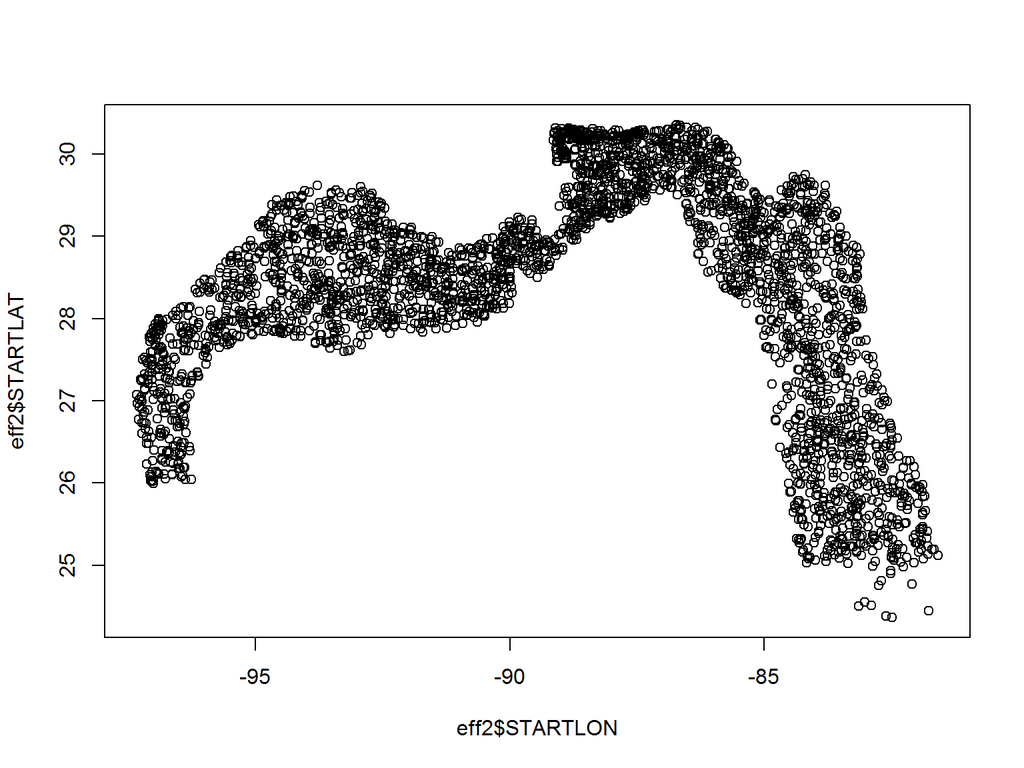

```r
par(mfrow=c(1,1))
plot(eff2$STARTLON,eff2$STARTLAT)
```

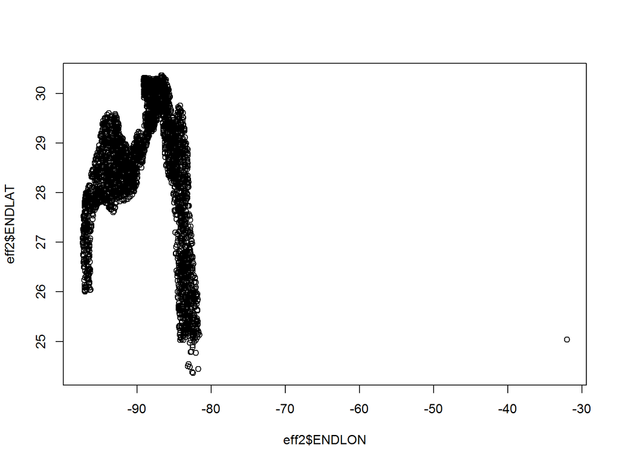

```r
plot(eff2$ENDLON,eff2$ENDLAT)
```

```r
#### outlier notes

range(eff2$SALBOTM, na.rm = TRUE)
```

```
## [1]  3.0000 48.7922
```

```r
(rm.Sal <- which(eff2$SALBOTM > 40 | eff2$SALBOTM < 15)) ### 507  932 2705 2770 2771 2941 2979
```

```
## [1]  507 2705 2979
```

```r
eff2[c(rm.Sal),c(1,42)]
```

|  | YEAR | SALBOTM |
| --- | --- | --- |
| 507 | 2000 | 3.0000 |
| 2705 | 2011 | 48.7922 |
| 2979 | 2013 | 11.9700 |

```r
#(rm.EndLon <- which(eff2$ENDLON > -80)) ### 1465 >>> just always use STARTLON and STARTLAT


range(eff2$OXYBOTM, na.rm = TRUE)
```

```
## [1]  0.0 12.2
```

```r
(oxy <- which(eff2$OXYBOTM == 0))
```

```
## [1]  99 100 338 339 411 652 823 824
```

```r
eff2[c(oxy),]
```

|  | YEAR | STATIONKEY | VESSEL | CRUISE | STATION | STARTLAT | STARTLON | STARTDEPTH | START_GMT | ENDLAT | ENDLON | ENDDEPTH | END_GMT | TIMEZONE | AREA | GOM_AREA | COUNCIL_AREA | CARIB_AREA | PROJECT | LLINEGEAR | HOOKTYPE | LLINEHOOKSIZE | NUMBERHOOKS | EFFORT | COMMENTS | HOOKCOUNT | FISHCOUNT | TEMPAIR | BAROPRES | … |
| --- | --- | --- | --- | --- | --- | --- | --- | --- | --- | --- | --- | --- | --- | --- | --- | --- | --- | --- | --- | --- | --- | --- | --- | --- | --- | --- | --- | --- | --- | --- |
| 99 | 1996 | 422200032 | 4 | 222 | 32 | 28.91217 | -90.12683 | 26.51760 | 8/9/1996 | 28.92700 | -90.12133 | 26.51760 | 8/9/1996 | GMT | Gulf of Mexico | Central Gulf | West | NA | PRIMARY | BL | J | 3 | 100 | 60 | set 0518/2855.67/9007.3/13.5f e.haul 0700/2854.8/9007.5/14.3f | 100 | NA | 29.0 | 1017.3 | … |
| 100 | 1996 | 422200033 | 4 | 222 | 33 | 29.10100 | -89.92433 | 20.11680 | 8/9/1996 | 29.08983 | -89.91033 | 21.94560 | 8/9/1996 | GMT | Gulf of Mexico | Central Gulf | West | NA | PRIMARY | BL | J | 3 | 100 | 60 | set 0842/2905.39/8954.64/12f e.haul 1025/2905.98/8955.38/11f | 100 | NA | 29.5 | 1017.8 | … |
| 338 | 1999 | 5599100031 | 55 | 991 | 31 | 28.72683 | -90.73067 | 17.19072 | 8/12/1999 | 28.73450 | -90.71317 | 16.45920 | 8/12/1999 | GMT | Gulf of Mexico | Central Gulf | West | NA | PRIMARY | BL | J | 3 | 100 | 60 | 0558/2844.07/9042.74/9.2f; | 100 | NA | NA | NA | … |
| 339 | 1999 | 5599100032 | 55 | 991 | 32 | 28.76300 | -90.96000 | 14.63040 | 8/12/1999 | 28.76683 | -90.94083 | 14.81328 | 8/12/1999 | GMT | Gulf of Mexico | Central Gulf | West | NA | PRIMARY | BL | J | 3 | 100 | 62 | 0907/2846.01/9056.44/8.2f; 1044/2845.8/9057.4/8f | 100 | NA | NA | NA | … |
| 411 | 1999 | 5599100022 | 55 | 991 | 22 | 28.90950 | -90.54667 | 13.35024 | 8/9/1999 | 28.91667 | -90.52833 | 12.98448 | 8/9/1999 | GMT | Gulf of Mexico | Central Gulf | West | NA | PRIMARY | BL | J | 3 | 100 | 64 | 1510/2855.04/9031.75/7.1f; 1659/2854.6/9032.59/7.2f | 100 | NA | NA | NA | … |
| 652 | 2001 | 424700055 | 4 | 247 | 55 | 29.05567 | -92.87783 | 25.23744 | 8/12/2001 | 29.07133 | -92.87983 | 24.14016 | 8/12/2001 | GMT | Gulf of Mexico | Central Gulf | West | NA | PRIMARY | BL | C | 15 | 100 | 62 | 0458/2904.46/9252.90/13.2; 0640/2903.56/9252.58/13.3 | 100 | NA | 29.6 | 1016.4 | … |
| 823 | 2001 | 424700054 | 4 | 247 | 54 | 29.16633 | -93.03083 | 19.38528 | 8/12/2001 | 29.18150 | -93.03517 | 19.56816 | 8/12/2001 | GMT | Gulf of Mexico | West Gulf | West | NA | PRIMARY | BL | C | 15 | 100 | 61 | 0157/2910.99/9302.19/10.6; 0347/2910.18/9301.79/10.6 | 100 | NA | 29.7 | 1016.0 | … |
| 824 | 2001 | 424700056 | 4 | 247 | 56 | 28.94183 | -93.11133 | 24.14016 | 8/12/2001 | 28.95750 | -93.10633 | 24.14016 | 8/12/2001 | GMT | Gulf of Mexico | West Gulf | West | NA | PRIMARY | BL | C | 15 | 100 | 60 | 0818/2857.33/9306.43/13.5; 0957/2856.58/9306.63/13.2 | 100 | NA | 29.7 | 1018.5 | … |

```r
(rm.Oxy <- which(eff2$OXYBOTM > 12 | eff2$OXYBOTM == 0)) ### 99 100 338 339 411 625 652 823 824
```

```
## [1]  99 100 338 339 411 625 652 823 824
```

```r
eff2[c(rm.Oxy),c(1,41,43:50)]
```

|  | YEAR | OXYBOTM | CARCHARHINUS.ACRONOTUS | CARCHARHINUS.BREVIPINNA | CARCHARHINUS.FALCIFORMIS | CARCHARHINUS.LEUCAS | CARCHARHINUS.LIMBATUS | CARCHARHINUS.PLUMBEUS | GALEOCERDO.CUVIER | RHIZOPRIONODON.TERRAENOVAE |
| --- | --- | --- | --- | --- | --- | --- | --- | --- | --- | --- |
| 99 | 1996 | 0.0 | 0.00000 | 0.0000000 | 0 | 0.0000000 | 0.000000 | 0 | 0 | 23.0000000 |
| 100 | 1996 | 0.0 | 0.00000 | 0.0000000 | 0 | 0.0000000 | 1.000000 | 0 | 0 | 0.0000000 |
| 338 | 1999 | 0.0 | 0.00000 | 0.0000000 | 0 | 0.0000000 | 0.000000 | 0 | 0 | 0.0000000 |
| 339 | 1999 | 0.0 | 0.00000 | 2.9032258 | 0 | 0.0000000 | 1.935484 | 0 | 0 | 0.0000000 |
| 411 | 1999 | 0.0 | 0.00000 | 0.9375000 | 0 | 0.0000000 | 1.875000 | 0 | 0 | 0.0000000 |
| 625 | 2000 | 12.2 | 0.00000 | 0.0000000 | 0 | 0.0000000 | 0.000000 | 0 | 0 | 0.8695652 |
| 652 | 2001 | 0.0 | 0.00000 | 1.9354839 | 0 | 0.0000000 | 0.000000 | 0 | 0 | 0.9677419 |
| 823 | 2001 | 0.0 | 2.95082 | 0.9836066 | 0 | 0.9836066 | 1.967213 | 0 | 0 | 15.7377049 |
| 824 | 2001 | 0.0 | 0.00000 | 0.0000000 | 0 | 0.0000000 | 0.000000 | 0 | 0 | 1.0000000 |

```r
 ### TURBBOTM and FLUOROBOTM are not used as explanitory variables so there is no need to remove outliers

#(rm.Turb <- which(eff2$TURBBOTM > 120)) ### 1994

#(rm.Fluo <-which(eff2$FLUOROBOTM > 30)) ### 1536, 1802, 2230, 2660, 2704


(n.rm <- length(rm.Sal) + length(rm.Oxy))
```

```
## [1] 12
```

Major outlier in **ENDLON**. I will just use STARTLAT and STARTLON.

Remove all **SALBOTM** lexx than 15 and more than 40, $n = $ 3.

Remove all **OXYBOTM** equal to 0 and greater than 12, $n =$ 9.

Keep outliers in **TURBBOTM** and **FLUOROBOTM** because we are not using these explanatory variables.

Total outliers to remove $n = $ 12.

### Remove outliers from eff2 df

```r
### Remove Outliers

  ### round 1 ###rm.EndLon
(rm1 <- c(rm.Sal,rm.Oxy))
```

```
##  [1]  507 2705 2979   99  100  338  339  411  625  652  823  824
```

```r
### round 2
#(rm2 <- c(rm.Oxy, rm.Turb, rm.Fluo))




eff2 <- eff2[-c(rm1),]
######

#str(eff2)
#write.csv(eff2,"data/CPUE3.csv", row.names = FALSE)
```

remaining data $n = $ 3149.

### create new species data.frames

```r
### CARCHARHINUS.ACRONOTUS (Blacknose)

### CARCHARHINUS.LIMBATUS (Blacktip)

### CARCHARHINUS.LEUCAS (Bull)

### CARCHARHINUS.PLUMBEUS (Sandbar)

### RHIZOPRIONODON.TERRAENOVAE (Sharpnose)

### CARCHARHINUS.FALCIFORMIS (Silky)

### CARCHARHINUS.BREVIPINNA (Spinner)

### GALEOCERDO.CUVIER (Tiger)

sp.df <- list(blacknose.df = acronotus.df <- extract.taxa.df.fun(eff2,
                             eff2$CARCHARHINUS.ACRONOTUS),

              blacktip.df = extract.taxa.df.fun(eff2,
                                     eff2$CARCHARHINUS.LIMBATUS),

              bull.df = extract.taxa.df.fun(eff2,
                                     eff2$CARCHARHINUS.LEUCAS),

              sandbar.df = extract.taxa.df.fun(eff2,
                                     eff2$CARCHARHINUS.PLUMBEUS),

              sharpnose.df = extract.taxa.df.fun(eff2,
                                     eff2$RHIZOPRIONODON.TERRAENOVAE),

              silky.df = extract.taxa.df.fun(eff2,
                                     eff2$CARCHARHINUS.FALCIFORMIS),

              spinner.df = extract.taxa.df.fun(eff2,
                                    eff2$CARCHARHINUS.BREVIPINNA),

              tiger.df = extract.taxa.df.fun(eff2,
                                     eff2$GALEOCERDO.CUVIER))
```

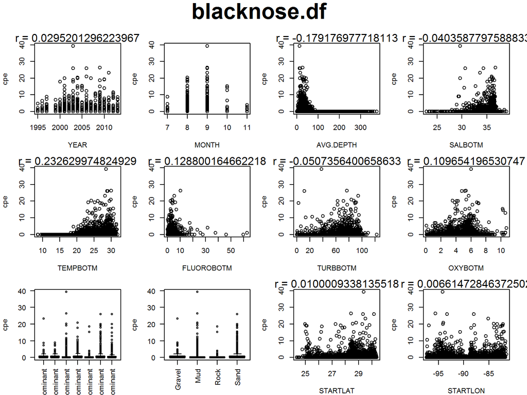

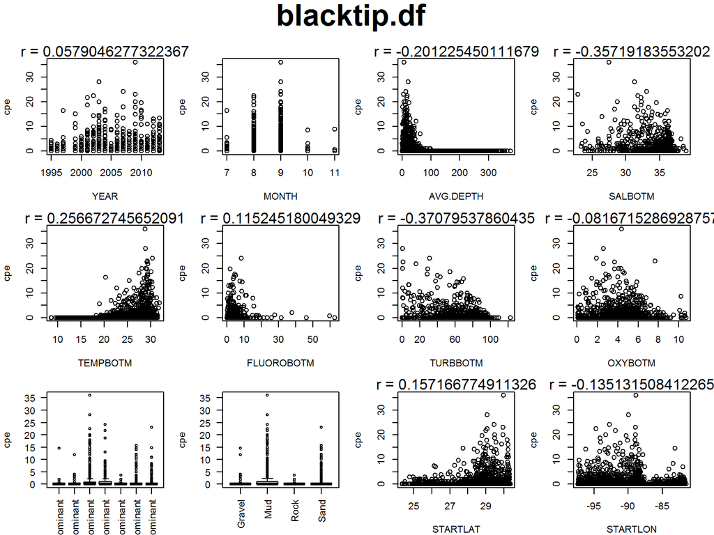

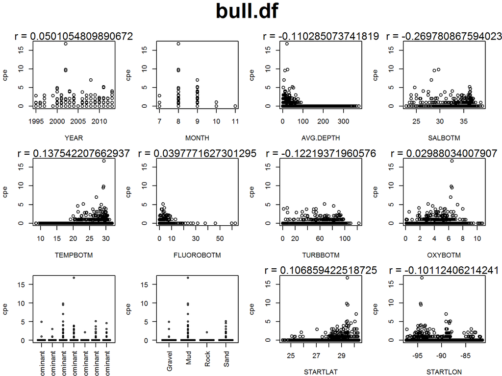

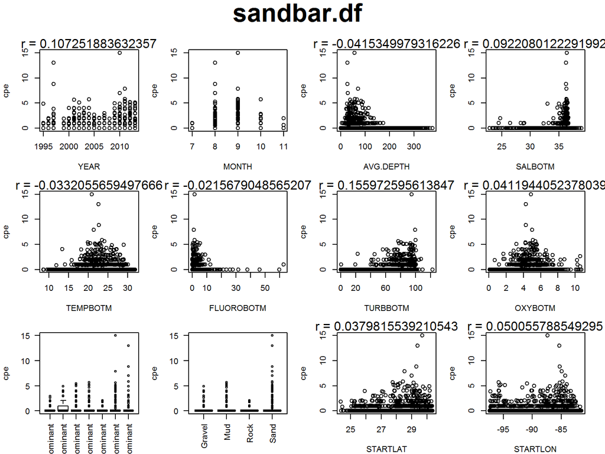

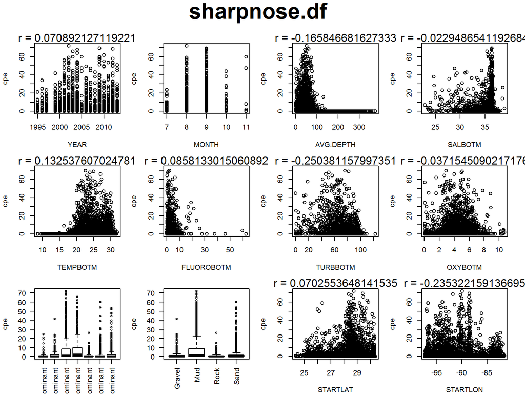

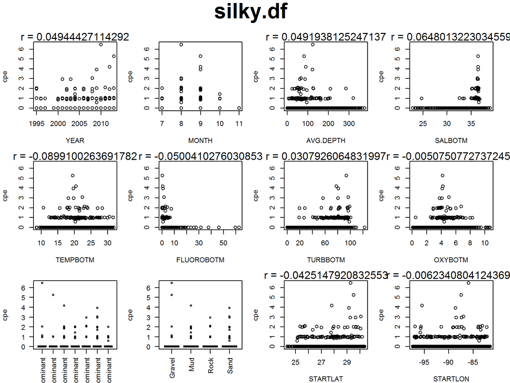

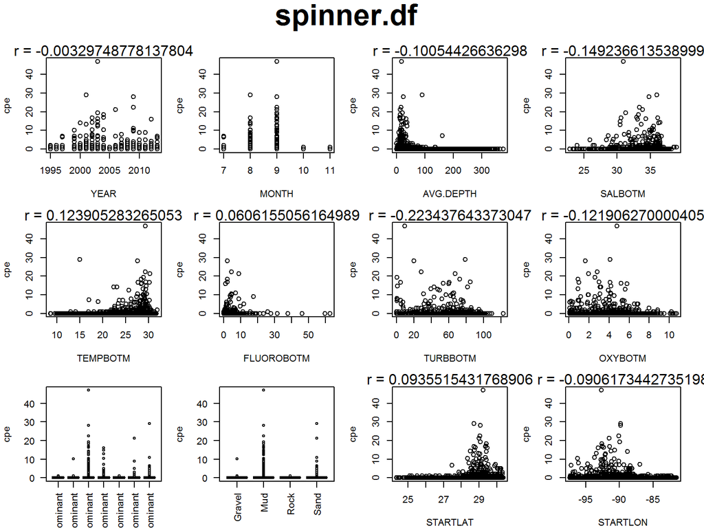

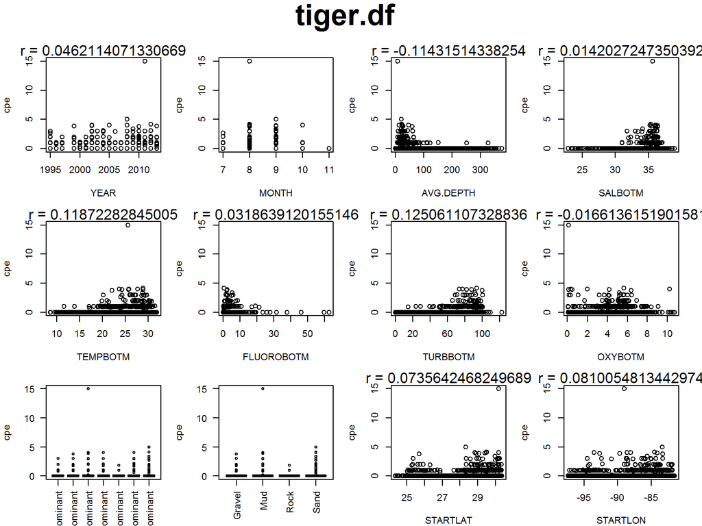

```r
scatter_fn(sp.df)
```

### Quick Look at data

```r
df.summary <- list(bn =  summary(sp.df[[1]]),
                   bt = summary(sp.df[[2]]),
                   bu = summary(sp.df[[3]]),
                   sb = summary(sp.df[[4]]),
                   sn = summary(sp.df[[5]]),
                   si = summary(sp.df[[6]]),
                   sp = summary(sp.df[[7]]),
                   ti = summary(sp.df[[8]]))
df.summary$bn
```

```
##       cpe               DATE                          YEAR      MONTH
##  Min.   : 0.0000   Min.   :1995-07-23 00:00:00   2003   : 280   Aug:1604
##  1st Qu.: 0.0000   1st Qu.:2001-09-08 00:00:00   2001   : 274   Jul:  90
##  Median : 0.0000   Median :2004-09-12 00:00:00   2004   : 249   Nov:   6
##  Mean   : 0.7885   Mean   :2005-06-22 23:31:50   2002   : 212   Oct:  54
##  3rd Qu.: 0.0000   3rd Qu.:2009-09-12 00:00:00   2009   : 211   Sep:1395
##  Max.   :39.3103   Max.   :2013-09-26 00:00:00   2007   : 184
##                                                  (Other):1739
##     STARTLAT        STARTLON          ENDLAT          ENDLON
##  Min.   :24.36   Min.   :-97.34   Min.   :24.36   Min.   :-97.35
##  1st Qu.:27.72   1st Qu.:-92.90   1st Qu.:27.71   1st Qu.:-92.89
##  Median :28.56   Median :-88.35   Median :28.56   Median :-88.35
##  Mean   :28.33   Mean   :-88.86   Mean   :28.33   Mean   :-88.85
##  3rd Qu.:29.31   3rd Qu.:-84.52   3rd Qu.:29.31   3rd Qu.:-84.51
##  Max.   :30.36   Max.   :-81.59   Max.   :30.37   Max.   :-32.03
##
##    STARTDEPTH        ENDDEPTH        AVG.DEPTH         TEMPBOTM
##  Min.   :  1.50   Min.   :  1.50   Min.   :  1.50   Min.   : 8.61
##  1st Qu.: 23.23   1st Qu.: 23.41   1st Qu.: 23.35   1st Qu.:20.27
##  Median : 41.70   Median : 41.70   Median : 41.61   Median :23.59
##  Mean   : 66.35   Mean   : 66.39   Mean   : 66.38   Mean   :23.37
##  3rd Qu.: 75.53   3rd Qu.: 76.08   3rd Qu.: 76.26   3rd Qu.:28.00
##  Max.   :375.00   Max.   :375.00   Max.   :375.00   Max.   :31.82
##                   NA's   :1        NA's   :1        NA's   :168
##    FLUOROBOTM        TURBBOTM         OXYBOTM            SALBOTM
##  Min.   : 0.000   Min.   :  0.00   Min.   : 0.09177   Min.   :22.90
##  1st Qu.: 0.440   1st Qu.: 63.23   1st Qu.: 3.73392   1st Qu.:35.50
##  Median : 1.718   Median : 76.94   Median : 4.50000   Median :36.14
##  Mean   : 2.793   Mean   : 73.09   Mean   : 4.56309   Mean   :35.48
##  3rd Qu.: 3.772   3rd Qu.: 87.40   3rd Qu.: 5.50373   3rd Qu.:36.40
##  Max.   :62.821   Max.   :122.36   Max.   :10.70234   Max.   :38.91
##  NA's   :1861     NA's   :920      NA's   :186        NA's   :179
##                dombot8       dombot4
##  Mud-Dominant      :1065   Gravel: 312
##  Sand-Dominant     : 687   Mud   :1468
##  Sand-Subdominant  : 538   Rock  : 106
##  Mud-Subdominant   : 403   Sand  :1225
##  Gravel-Subdominant: 189   NA's  :  38
##  (Other)           : 229
##  NA's              :  38
```

```r
df.summary$bt
```

```
##       cpe               DATE                          YEAR      MONTH
##  Min.   : 0.0000   Min.   :1995-07-23 00:00:00   2003   : 280   Aug:1604
##  1st Qu.: 0.0000   1st Qu.:2001-09-08 00:00:00   2001   : 274   Jul:  90
##  Median : 0.0000   Median :2004-09-12 00:00:00   2004   : 249   Nov:   6
##  Mean   : 0.6859   Mean   :2005-06-22 23:31:50   2002   : 212   Oct:  54
##  3rd Qu.: 0.0000   3rd Qu.:2009-09-12 00:00:00   2009   : 211   Sep:1395
##  Max.   :36.0000   Max.   :2013-09-26 00:00:00   2007   : 184
##                                                  (Other):1739
##     STARTLAT        STARTLON          ENDLAT          ENDLON
##  Min.   :24.36   Min.   :-97.34   Min.   :24.36   Min.   :-97.35
##  1st Qu.:27.72   1st Qu.:-92.90   1st Qu.:27.71   1st Qu.:-92.89
##  Median :28.56   Median :-88.35   Median :28.56   Median :-88.35
##  Mean   :28.33   Mean   :-88.86   Mean   :28.33   Mean   :-88.85
##  3rd Qu.:29.31   3rd Qu.:-84.52   3rd Qu.:29.31   3rd Qu.:-84.51
##  Max.   :30.36   Max.   :-81.59   Max.   :30.37   Max.   :-32.03
##
##    STARTDEPTH        ENDDEPTH        AVG.DEPTH         TEMPBOTM
##  Min.   :  1.50   Min.   :  1.50   Min.   :  1.50   Min.   : 8.61
##  1st Qu.: 23.23   1st Qu.: 23.41   1st Qu.: 23.35   1st Qu.:20.27
##  Median : 41.70   Median : 41.70   Median : 41.61   Median :23.59
##  Mean   : 66.35   Mean   : 66.39   Mean   : 66.38   Mean   :23.37
##  3rd Qu.: 75.53   3rd Qu.: 76.08   3rd Qu.: 76.26   3rd Qu.:28.00
##  Max.   :375.00   Max.   :375.00   Max.   :375.00   Max.   :31.82
##                   NA's   :1        NA's   :1        NA's   :168
##    FLUOROBOTM        TURBBOTM         OXYBOTM            SALBOTM
##  Min.   : 0.000   Min.   :  0.00   Min.   : 0.09177   Min.   :22.90
##  1st Qu.: 0.440   1st Qu.: 63.23   1st Qu.: 3.73392   1st Qu.:35.50
##  Median : 1.718   Median : 76.94   Median : 4.50000   Median :36.14
##  Mean   : 2.793   Mean   : 73.09   Mean   : 4.56309   Mean   :35.48
##  3rd Qu.: 3.772   3rd Qu.: 87.40   3rd Qu.: 5.50373   3rd Qu.:36.40
##  Max.   :62.821   Max.   :122.36   Max.   :10.70234   Max.   :38.91
##  NA's   :1861     NA's   :920      NA's   :186        NA's   :179
##                dombot8       dombot4
##  Mud-Dominant      :1065   Gravel: 312
##  Sand-Dominant     : 687   Mud   :1468
##  Sand-Subdominant  : 538   Rock  : 106
##  Mud-Subdominant   : 403   Sand  :1225
##  Gravel-Subdominant: 189   NA's  :  38
##  (Other)           : 229
##  NA's              :  38
```

```r
df.summary$bu
```

```
##       cpe               DATE                          YEAR      MONTH
##  Min.   : 0.0000   Min.   :1995-07-23 00:00:00   2003   : 280   Aug:1604
##  1st Qu.: 0.0000   1st Qu.:2001-09-08 00:00:00   2001   : 274   Jul:  90
##  Median : 0.0000   Median :2004-09-12 00:00:00   2004   : 249   Nov:   6
##  Mean   : 0.1038   Mean   :2005-06-22 23:31:50   2002   : 212   Oct:  54
##  3rd Qu.: 0.0000   3rd Qu.:2009-09-12 00:00:00   2009   : 211   Sep:1395
##  Max.   :16.7213   Max.   :2013-09-26 00:00:00   2007   : 184
##                                                  (Other):1739
##     STARTLAT        STARTLON          ENDLAT          ENDLON
##  Min.   :24.36   Min.   :-97.34   Min.   :24.36   Min.   :-97.35
##  1st Qu.:27.72   1st Qu.:-92.90   1st Qu.:27.71   1st Qu.:-92.89
##  Median :28.56   Median :-88.35   Median :28.56   Median :-88.35
##  Mean   :28.33   Mean   :-88.86   Mean   :28.33   Mean   :-88.85
##  3rd Qu.:29.31   3rd Qu.:-84.52   3rd Qu.:29.31   3rd Qu.:-84.51
##  Max.   :30.36   Max.   :-81.59   Max.   :30.37   Max.   :-32.03
##
##    STARTDEPTH        ENDDEPTH        AVG.DEPTH         TEMPBOTM
##  Min.   :  1.50   Min.   :  1.50   Min.   :  1.50   Min.   : 8.61
##  1st Qu.: 23.23   1st Qu.: 23.41   1st Qu.: 23.35   1st Qu.:20.27
##  Median : 41.70   Median : 41.70   Median : 41.61   Median :23.59
##  Mean   : 66.35   Mean   : 66.39   Mean   : 66.38   Mean   :23.37
##  3rd Qu.: 75.53   3rd Qu.: 76.08   3rd Qu.: 76.26   3rd Qu.:28.00
##  Max.   :375.00   Max.   :375.00   Max.   :375.00   Max.   :31.82
##                   NA's   :1        NA's   :1        NA's   :168
##    FLUOROBOTM        TURBBOTM         OXYBOTM            SALBOTM
##  Min.   : 0.000   Min.   :  0.00   Min.   : 0.09177   Min.   :22.90
##  1st Qu.: 0.440   1st Qu.: 63.23   1st Qu.: 3.73392   1st Qu.:35.50
##  Median : 1.718   Median : 76.94   Median : 4.50000   Median :36.14
##  Mean   : 2.793   Mean   : 73.09   Mean   : 4.56309   Mean   :35.48
##  3rd Qu.: 3.772   3rd Qu.: 87.40   3rd Qu.: 5.50373   3rd Qu.:36.40
##  Max.   :62.821   Max.   :122.36   Max.   :10.70234   Max.   :38.91
##  NA's   :1861     NA's   :920      NA's   :186        NA's   :179
##                dombot8       dombot4
##  Mud-Dominant      :1065   Gravel: 312
##  Sand-Dominant     : 687   Mud   :1468
##  Sand-Subdominant  : 538   Rock  : 106
##  Mud-Subdominant   : 403   Sand  :1225
##  Gravel-Subdominant: 189   NA's  :  38
##  (Other)           : 229
##  NA's              :  38
```

```r
df.summary$sb
```

```
##       cpe               DATE                          YEAR      MONTH
##  Min.   : 0.0000   Min.   :1995-07-23 00:00:00   2003   : 280   Aug:1604
##  1st Qu.: 0.0000   1st Qu.:2001-09-08 00:00:00   2001   : 274   Jul:  90
##  Median : 0.0000   Median :2004-09-12 00:00:00   2004   : 249   Nov:   6
##  Mean   : 0.2319   Mean   :2005-06-22 23:31:50   2002   : 212   Oct:  54
##  3rd Qu.: 0.0000   3rd Qu.:2009-09-12 00:00:00   2009   : 211   Sep:1395
##  Max.   :15.0000   Max.   :2013-09-26 00:00:00   2007   : 184
##                                                  (Other):1739
##     STARTLAT        STARTLON          ENDLAT          ENDLON
##  Min.   :24.36   Min.   :-97.34   Min.   :24.36   Min.   :-97.35
##  1st Qu.:27.72   1st Qu.:-92.90   1st Qu.:27.71   1st Qu.:-92.89
##  Median :28.56   Median :-88.35   Median :28.56   Median :-88.35
##  Mean   :28.33   Mean   :-88.86   Mean   :28.33   Mean   :-88.85
##  3rd Qu.:29.31   3rd Qu.:-84.52   3rd Qu.:29.31   3rd Qu.:-84.51
##  Max.   :30.36   Max.   :-81.59   Max.   :30.37   Max.   :-32.03
##
##    STARTDEPTH        ENDDEPTH        AVG.DEPTH         TEMPBOTM
##  Min.   :  1.50   Min.   :  1.50   Min.   :  1.50   Min.   : 8.61
##  1st Qu.: 23.23   1st Qu.: 23.41   1st Qu.: 23.35   1st Qu.:20.27
##  Median : 41.70   Median : 41.70   Median : 41.61   Median :23.59
##  Mean   : 66.35   Mean   : 66.39   Mean   : 66.38   Mean   :23.37
##  3rd Qu.: 75.53   3rd Qu.: 76.08   3rd Qu.: 76.26   3rd Qu.:28.00
##  Max.   :375.00   Max.   :375.00   Max.   :375.00   Max.   :31.82
##                   NA's   :1        NA's   :1        NA's   :168
##    FLUOROBOTM        TURBBOTM         OXYBOTM            SALBOTM
##  Min.   : 0.000   Min.   :  0.00   Min.   : 0.09177   Min.   :22.90
##  1st Qu.: 0.440   1st Qu.: 63.23   1st Qu.: 3.73392   1st Qu.:35.50
##  Median : 1.718   Median : 76.94   Median : 4.50000   Median :36.14
##  Mean   : 2.793   Mean   : 73.09   Mean   : 4.56309   Mean   :35.48
##  3rd Qu.: 3.772   3rd Qu.: 87.40   3rd Qu.: 5.50373   3rd Qu.:36.40
##  Max.   :62.821   Max.   :122.36   Max.   :10.70234   Max.   :38.91
##  NA's   :1861     NA's   :920      NA's   :186        NA's   :179
##                dombot8       dombot4
##  Mud-Dominant      :1065   Gravel: 312
##  Sand-Dominant     : 687   Mud   :1468
##  Sand-Subdominant  : 538   Rock  : 106
##  Mud-Subdominant   : 403   Sand  :1225
##  Gravel-Subdominant: 189   NA's  :  38
##  (Other)           : 229
##  NA's              :  38
```

```r
df.summary$sn
```

```
##       cpe              DATE                          YEAR      MONTH
##  Min.   : 0.000   Min.   :1995-07-23 00:00:00   2003   : 280   Aug:1604
##  1st Qu.: 0.000   1st Qu.:2001-09-08 00:00:00   2001   : 274   Jul:  90
##  Median : 0.000   Median :2004-09-12 00:00:00   2004   : 249   Nov:   6
##  Mean   : 4.529   Mean   :2005-06-22 23:31:50   2002   : 212   Oct:  54
##  3rd Qu.: 4.000   3rd Qu.:2009-09-12 00:00:00   2009   : 211   Sep:1395
##  Max.   :72.000   Max.   :2013-09-26 00:00:00   2007   : 184
##                                                 (Other):1739
##     STARTLAT        STARTLON          ENDLAT          ENDLON
##  Min.   :24.36   Min.   :-97.34   Min.   :24.36   Min.   :-97.35
##  1st Qu.:27.72   1st Qu.:-92.90   1st Qu.:27.71   1st Qu.:-92.89
##  Median :28.56   Median :-88.35   Median :28.56   Median :-88.35
##  Mean   :28.33   Mean   :-88.86   Mean   :28.33   Mean   :-88.85
##  3rd Qu.:29.31   3rd Qu.:-84.52   3rd Qu.:29.31   3rd Qu.:-84.51
##  Max.   :30.36   Max.   :-81.59   Max.   :30.37   Max.   :-32.03
##
##    STARTDEPTH        ENDDEPTH        AVG.DEPTH         TEMPBOTM
##  Min.   :  1.50   Min.   :  1.50   Min.   :  1.50   Min.   : 8.61
##  1st Qu.: 23.23   1st Qu.: 23.41   1st Qu.: 23.35   1st Qu.:20.27
##  Median : 41.70   Median : 41.70   Median : 41.61   Median :23.59
##  Mean   : 66.35   Mean   : 66.39   Mean   : 66.38   Mean   :23.37
##  3rd Qu.: 75.53   3rd Qu.: 76.08   3rd Qu.: 76.26   3rd Qu.:28.00
##  Max.   :375.00   Max.   :375.00   Max.   :375.00   Max.   :31.82
##                   NA's   :1        NA's   :1        NA's   :168
##    FLUOROBOTM        TURBBOTM         OXYBOTM            SALBOTM
##  Min.   : 0.000   Min.   :  0.00   Min.   : 0.09177   Min.   :22.90
##  1st Qu.: 0.440   1st Qu.: 63.23   1st Qu.: 3.73392   1st Qu.:35.50
##  Median : 1.718   Median : 76.94   Median : 4.50000   Median :36.14
##  Mean   : 2.793   Mean   : 73.09   Mean   : 4.56309   Mean   :35.48
##  3rd Qu.: 3.772   3rd Qu.: 87.40   3rd Qu.: 5.50373   3rd Qu.:36.40
##  Max.   :62.821   Max.   :122.36   Max.   :10.70234   Max.   :38.91
##  NA's   :1861     NA's   :920      NA's   :186        NA's   :179
##                dombot8       dombot4
##  Mud-Dominant      :1065   Gravel: 312
##  Sand-Dominant     : 687   Mud   :1468
##  Sand-Subdominant  : 538   Rock  : 106
##  Mud-Subdominant   : 403   Sand  :1225
##  Gravel-Subdominant: 189   NA's  :  38
##  (Other)           : 229
##  NA's              :  38
```

```r
df.summary$si
```

```
##       cpe               DATE                          YEAR      MONTH
##  Min.   :0.00000   Min.   :1995-07-23 00:00:00   2003   : 280   Aug:1604
##  1st Qu.:0.00000   1st Qu.:2001-09-08 00:00:00   2001   : 274   Jul:  90
##  Median :0.00000   Median :2004-09-12 00:00:00   2004   : 249   Nov:   6
##  Mean   :0.05323   Mean   :2005-06-22 23:31:50   2002   : 212   Oct:  54
##  3rd Qu.:0.00000   3rd Qu.:2009-09-12 00:00:00   2009   : 211   Sep:1395
##  Max.   :6.46154   Max.   :2013-09-26 00:00:00   2007   : 184
##                                                  (Other):1739
##     STARTLAT        STARTLON          ENDLAT          ENDLON
##  Min.   :24.36   Min.   :-97.34   Min.   :24.36   Min.   :-97.35
##  1st Qu.:27.72   1st Qu.:-92.90   1st Qu.:27.71   1st Qu.:-92.89
##  Median :28.56   Median :-88.35   Median :28.56   Median :-88.35
##  Mean   :28.33   Mean   :-88.86   Mean   :28.33   Mean   :-88.85
##  3rd Qu.:29.31   3rd Qu.:-84.52   3rd Qu.:29.31   3rd Qu.:-84.51
##  Max.   :30.36   Max.   :-81.59   Max.   :30.37   Max.   :-32.03
##
##    STARTDEPTH        ENDDEPTH        AVG.DEPTH         TEMPBOTM
##  Min.   :  1.50   Min.   :  1.50   Min.   :  1.50   Min.   : 8.61
##  1st Qu.: 23.23   1st Qu.: 23.41   1st Qu.: 23.35   1st Qu.:20.27
##  Median : 41.70   Median : 41.70   Median : 41.61   Median :23.59
##  Mean   : 66.35   Mean   : 66.39   Mean   : 66.38   Mean   :23.37
##  3rd Qu.: 75.53   3rd Qu.: 76.08   3rd Qu.: 76.26   3rd Qu.:28.00
##  Max.   :375.00   Max.   :375.00   Max.   :375.00   Max.   :31.82
##                   NA's   :1        NA's   :1        NA's   :168
##    FLUOROBOTM        TURBBOTM         OXYBOTM            SALBOTM
##  Min.   : 0.000   Min.   :  0.00   Min.   : 0.09177   Min.   :22.90
##  1st Qu.: 0.440   1st Qu.: 63.23   1st Qu.: 3.73392   1st Qu.:35.50
##  Median : 1.718   Median : 76.94   Median : 4.50000   Median :36.14
##  Mean   : 2.793   Mean   : 73.09   Mean   : 4.56309   Mean   :35.48
##  3rd Qu.: 3.772   3rd Qu.: 87.40   3rd Qu.: 5.50373   3rd Qu.:36.40
##  Max.   :62.821   Max.   :122.36   Max.   :10.70234   Max.   :38.91
##  NA's   :1861     NA's   :920      NA's   :186        NA's   :179
##                dombot8       dombot4
##  Mud-Dominant      :1065   Gravel: 312
##  Sand-Dominant     : 687   Mud   :1468
##  Sand-Subdominant  : 538   Rock  : 106
##  Mud-Subdominant   : 403   Sand  :1225
##  Gravel-Subdominant: 189   NA's  :  38
##  (Other)           : 229
##  NA's              :  38
```

```r
df.summary$sp
```

```
##       cpe               DATE                          YEAR      MONTH
##  Min.   : 0.0000   Min.   :1995-07-23 00:00:00   2003   : 280   Aug:1604
##  1st Qu.: 0.0000   1st Qu.:2001-09-08 00:00:00   2001   : 274   Jul:  90
##  Median : 0.0000   Median :2004-09-12 00:00:00   2004   : 249   Nov:   6
##  Mean   : 0.3018   Mean   :2005-06-22 23:31:50   2002   : 212   Oct:  54
##  3rd Qu.: 0.0000   3rd Qu.:2009-09-12 00:00:00   2009   : 211   Sep:1395
##  Max.   :47.0000   Max.   :2013-09-26 00:00:00   2007   : 184
##                                                  (Other):1739
##     STARTLAT        STARTLON          ENDLAT          ENDLON
##  Min.   :24.36   Min.   :-97.34   Min.   :24.36   Min.   :-97.35
##  1st Qu.:27.72   1st Qu.:-92.90   1st Qu.:27.71   1st Qu.:-92.89
##  Median :28.56   Median :-88.35   Median :28.56   Median :-88.35
##  Mean   :28.33   Mean   :-88.86   Mean   :28.33   Mean   :-88.85
##  3rd Qu.:29.31   3rd Qu.:-84.52   3rd Qu.:29.31   3rd Qu.:-84.51
##  Max.   :30.36   Max.   :-81.59   Max.   :30.37   Max.   :-32.03
##
##    STARTDEPTH        ENDDEPTH        AVG.DEPTH         TEMPBOTM
##  Min.   :  1.50   Min.   :  1.50   Min.   :  1.50   Min.   : 8.61
##  1st Qu.: 23.23   1st Qu.: 23.41   1st Qu.: 23.35   1st Qu.:20.27
##  Median : 41.70   Median : 41.70   Median : 41.61   Median :23.59
##  Mean   : 66.35   Mean   : 66.39   Mean   : 66.38   Mean   :23.37
##  3rd Qu.: 75.53   3rd Qu.: 76.08   3rd Qu.: 76.26   3rd Qu.:28.00
##  Max.   :375.00   Max.   :375.00   Max.   :375.00   Max.   :31.82
##                   NA's   :1        NA's   :1        NA's   :168
##    FLUOROBOTM        TURBBOTM         OXYBOTM            SALBOTM
##  Min.   : 0.000   Min.   :  0.00   Min.   : 0.09177   Min.   :22.90
##  1st Qu.: 0.440   1st Qu.: 63.23   1st Qu.: 3.73392   1st Qu.:35.50
##  Median : 1.718   Median : 76.94   Median : 4.50000   Median :36.14
##  Mean   : 2.793   Mean   : 73.09   Mean   : 4.56309   Mean   :35.48
##  3rd Qu.: 3.772   3rd Qu.: 87.40   3rd Qu.: 5.50373   3rd Qu.:36.40
##  Max.   :62.821   Max.   :122.36   Max.   :10.70234   Max.   :38.91
##  NA's   :1861     NA's   :920      NA's   :186        NA's   :179
##                dombot8       dombot4
##  Mud-Dominant      :1065   Gravel: 312
##  Sand-Dominant     : 687   Mud   :1468
##  Sand-Subdominant  : 538   Rock  : 106
##  Mud-Subdominant   : 403   Sand  :1225
##  Gravel-Subdominant: 189   NA's  :  38
##  (Other)           : 229
##  NA's              :  38
```

```r
df.summary$ti
```

```
##       cpe               DATE                          YEAR      MONTH
##  Min.   : 0.0000   Min.   :1995-07-23 00:00:00   2003   : 280   Aug:1604
##  1st Qu.: 0.0000   1st Qu.:2001-09-08 00:00:00   2001   : 274   Jul:  90
##  Median : 0.0000   Median :2004-09-12 00:00:00   2004   : 249   Nov:   6
##  Mean   : 0.1227   Mean   :2005-06-22 23:31:50   2002   : 212   Oct:  54
##  3rd Qu.: 0.0000   3rd Qu.:2009-09-12 00:00:00   2009   : 211   Sep:1395
##  Max.   :15.0000   Max.   :2013-09-26 00:00:00   2007   : 184
##                                                  (Other):1739
##     STARTLAT        STARTLON          ENDLAT          ENDLON
##  Min.   :24.36   Min.   :-97.34   Min.   :24.36   Min.   :-97.35
##  1st Qu.:27.72   1st Qu.:-92.90   1st Qu.:27.71   1st Qu.:-92.89
##  Median :28.56   Median :-88.35   Median :28.56   Median :-88.35
##  Mean   :28.33   Mean   :-88.86   Mean   :28.33   Mean   :-88.85
##  3rd Qu.:29.31   3rd Qu.:-84.52   3rd Qu.:29.31   3rd Qu.:-84.51
##  Max.   :30.36   Max.   :-81.59   Max.   :30.37   Max.   :-32.03
##
##    STARTDEPTH        ENDDEPTH        AVG.DEPTH         TEMPBOTM
##  Min.   :  1.50   Min.   :  1.50   Min.   :  1.50   Min.   : 8.61
##  1st Qu.: 23.23   1st Qu.: 23.41   1st Qu.: 23.35   1st Qu.:20.27
##  Median : 41.70   Median : 41.70   Median : 41.61   Median :23.59
##  Mean   : 66.35   Mean   : 66.39   Mean   : 66.38   Mean   :23.37
##  3rd Qu.: 75.53   3rd Qu.: 76.08   3rd Qu.: 76.26   3rd Qu.:28.00
##  Max.   :375.00   Max.   :375.00   Max.   :375.00   Max.   :31.82
##                   NA's   :1        NA's   :1        NA's   :168
##    FLUOROBOTM        TURBBOTM         OXYBOTM            SALBOTM
##  Min.   : 0.000   Min.   :  0.00   Min.   : 0.09177   Min.   :22.90
##  1st Qu.: 0.440   1st Qu.: 63.23   1st Qu.: 3.73392   1st Qu.:35.50
##  Median : 1.718   Median : 76.94   Median : 4.50000   Median :36.14
##  Mean   : 2.793   Mean   : 73.09   Mean   : 4.56309   Mean   :35.48
##  3rd Qu.: 3.772   3rd Qu.: 87.40   3rd Qu.: 5.50373   3rd Qu.:36.40
##  Max.   :62.821   Max.   :122.36   Max.   :10.70234   Max.   :38.91
##  NA's   :1861     NA's   :920      NA's   :186        NA's   :179
##                dombot8       dombot4
##  Mud-Dominant      :1065   Gravel: 312
##  Sand-Dominant     : 687   Mud   :1468
##  Sand-Subdominant  : 538   Rock  : 106
##  Mud-Subdominant   : 403   Sand  :1225
##  Gravel-Subdominant: 189   NA's  :  38
##  (Other)           : 229
##  NA's              :  38
```

## Model Development

### Response Variable Transformations

I want to see if Logging *cpe* will make it more normally distributed. Keep in mind cpe will only include positive catch as a response variable so I’ll have to remove all zeroe cpes. Then I will move on to the explanatory variables.

##### Removing zero CPUE

```r
length(sp.df[[1]]$cpe)
```

```
## [1] 3149
```

```r
for(i in 1:length(sp.df)){
  sp.df[[i]] %<>% subset(cpe > 0)
}


length(sp.df[[1]]$cpe)
```

```
## [1] 787
```

#### Histograms of CPUEAll Species

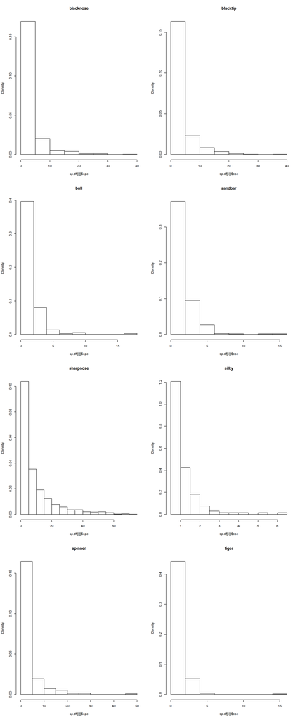

```r
par(mfrow = c(1,1))
par(mfrow = c(4,2))


for(i in 1:length(sp.df)){

    hist(sp.df[[i]]$cpe,
         freq=FALSE,
         main = names(sp.df[i]))

  }
```

##### log cpe

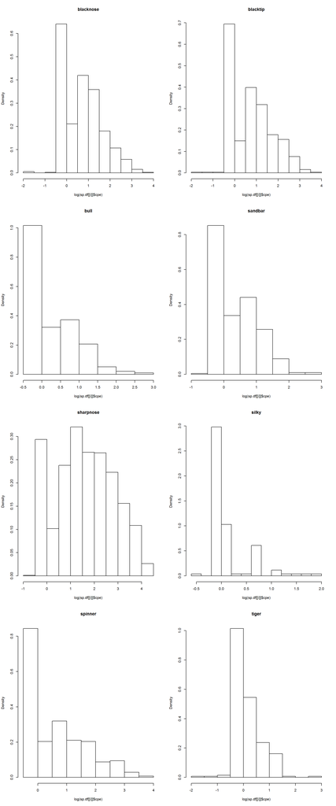

```r
par(mfrow = c(1,1))

par(mfrow = c(4,2))

for(i in 1:length(sp.df)){

    hist(log(sp.df[[i]]$cpe),
         freq=FALSE,
         main = names(sp.df[i]))

  }
```

##### log cpe +1

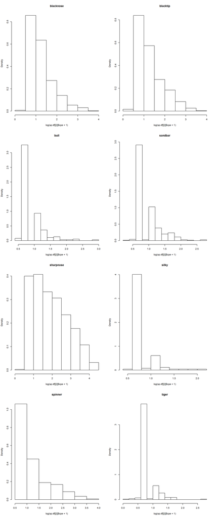

```r
par(mfrow = c(4,2))

for(i in 1:length(sp.df)){

    hist(log(sp.df[[i]]$cpe +1),
         freq=FALSE,
         main = names(sp.df[i]))

  }
```

##### log cpe + 0.1

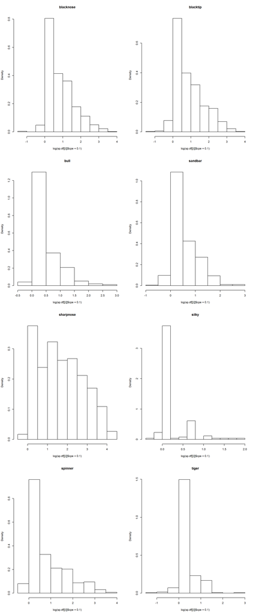

```r
par(mfrow = c(4,2))

for(i in 1:length(sp.df)){

    hist(log(sp.df[[i]]$cpe +0.1),
         freq=FALSE,
         main = names(sp.df[i]))

  }
```

##### Mean centered cpe

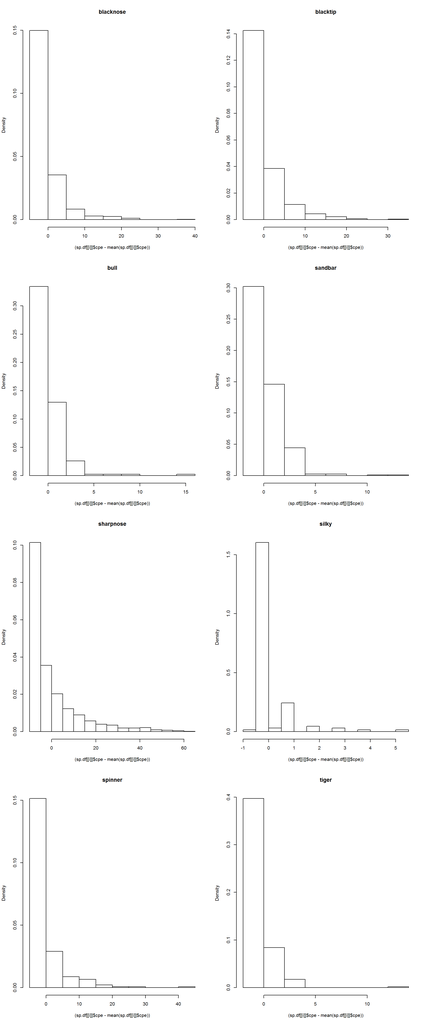

```r
par(mfrow = c(4,2))

for(i in 1:length(sp.df)){

    hist((sp.df[[i]]$cpe- mean(sp.df[[i]]$cpe)),
         freq=FALSE,
         main = names(sp.df[i]))

  }
```

##### Standardized cpe

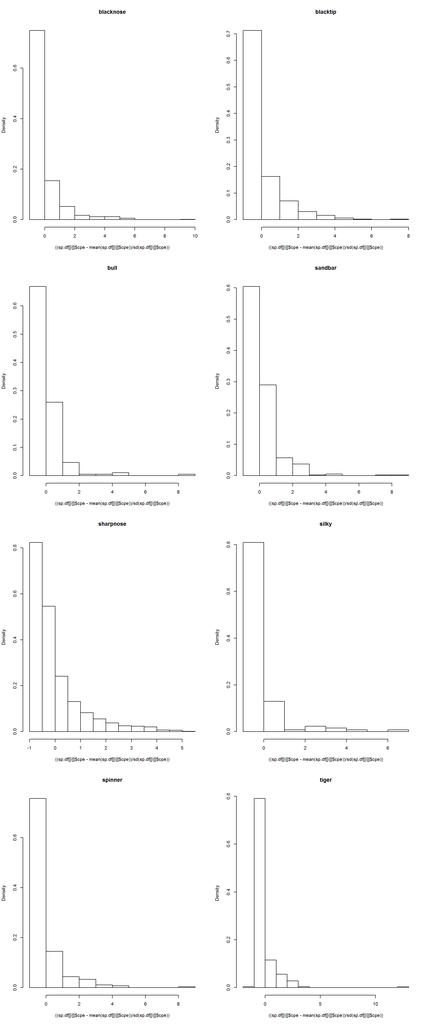

```r
par(mfrow = c(4,2))

for(i in 1:length(sp.df)){

    hist(((sp.df[[i]]$cpe- mean(sp.df[[i]]$cpe))/sd(sp.df[[i]]$cpe)),
         freq=FALSE,
         main = names(sp.df[i]))

  }
```

It looks like the best treatment for the response variable should be the log of the CPUE.

$$g_{1}(y) = log(CPUE)$$

### Explanatory variable transformations

It may be important to loog at the variables both with and without 0 CPUE values since I will be removing the zeroes for the second strata model.

#### With Zeros Strata 1

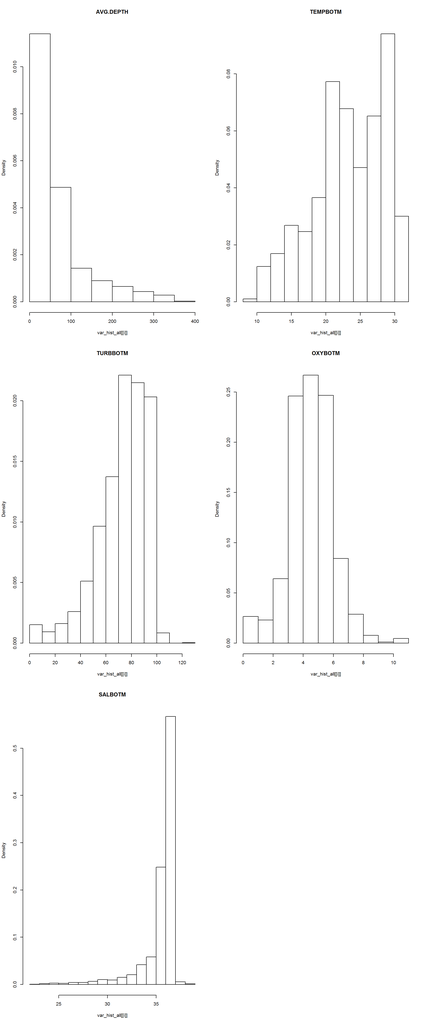

```r
var_hist_all <- sp.df_All[[1]]

var_hist_all %<>%
  select("AVG.DEPTH", "TEMPBOTM", "TURBBOTM", "OXYBOTM", "SALBOTM")


par(mfrow = c(3,2))

for(i in 1:length(var_hist_all)){
  hist(var_hist_all[[i]],
       freq = FALSE,
       main = names(var_hist_all[i]))
}
```

Looks like **AVG.DEPTH** is a clear canidate for transformation. Other possible canidates **SALBOTM**, **TEMPBOTM**, **TURBBOTM**.

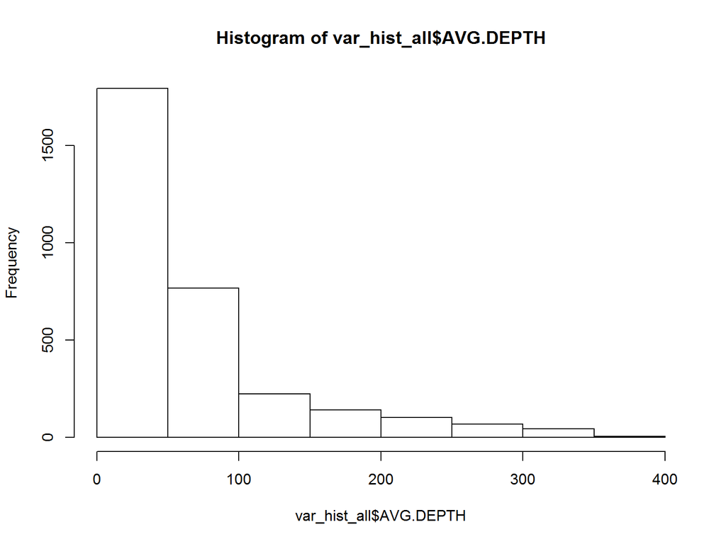

```r
par(mfrow = c(1,1))


hist(var_hist_all$AVG.DEPTH)
```

##### Log AVG.DEPTH

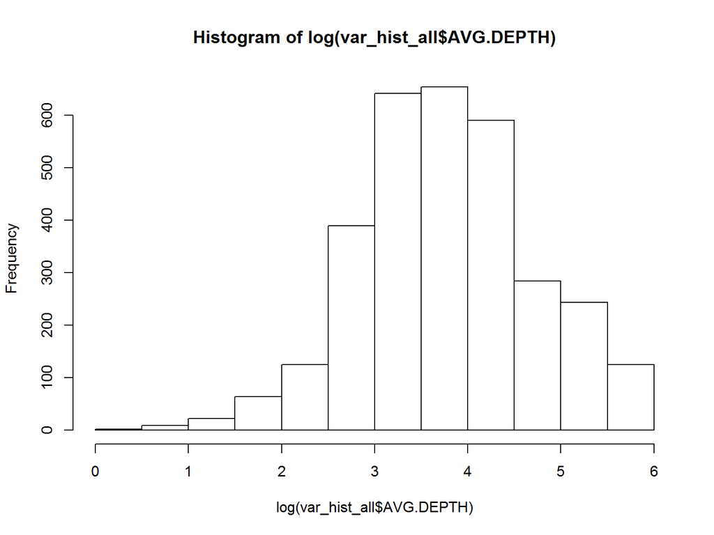

```r
hist(log(var_hist_all$AVG.DEPTH))
```

##### square root AVG.DEPTH

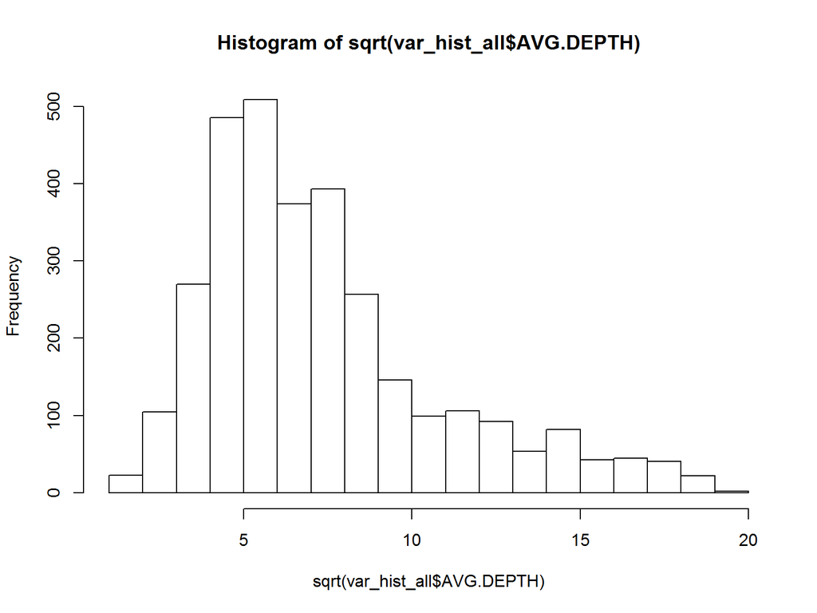

```r
hist(sqrt(var_hist_all$AVG.DEPTH))
```

##### 4th root AVG.DEPTH

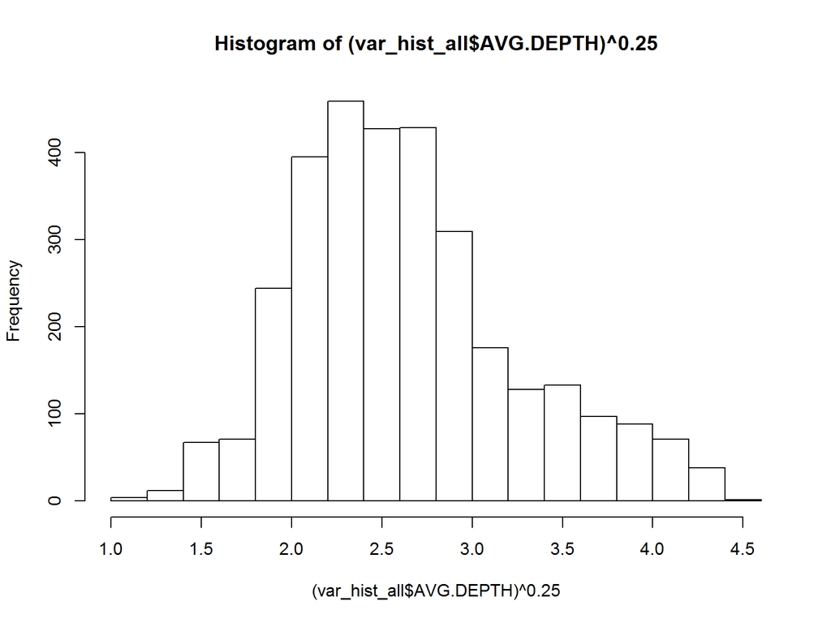

```r
hist((var_hist_all$AVG.DEPTH)^0.25)
```

The 4th root of **AVG.DEPTH** looks the best to me but lets leave this for now to see if it actually improves the model fit later.

#### No Zeros Strata2

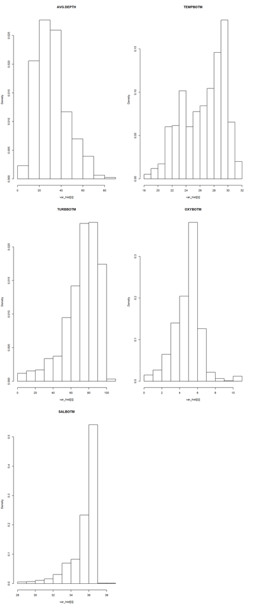

```r
var_hist <- sp.df[[1]]

var_hist %<>%
  select("AVG.DEPTH", "TEMPBOTM", "TURBBOTM", "OXYBOTM", "SALBOTM")


par(mfrow = c(3,2))

for(i in 1:length(var_hist)){
  hist(var_hist[[i]],
       freq = FALSE,
       main = names(var_hist[i]))
}
```

The response variables look pretty ok to me. possible canidates are **AVG.DEPTH**, **TEMPBOTM**, **TURBBOTM**, and **SALBOTM**.

I’m going to leave these alone for now and see how the models come out.

### AIC Check

I need to see if increasing the number of basis dimensions (k) affects the AIC score. I think it will because for each k within a spline one additional knot or $\beta$ is created and these are accounted for in the maximum degrees of freedom, which, is accounted for in the calculation of AIC.

$$AIC = 2K - 2ln(\hat{L})$$
Where $K$ is the number of parameters and $\hat{L}$ is the maximum value of the liklihood function of the model.

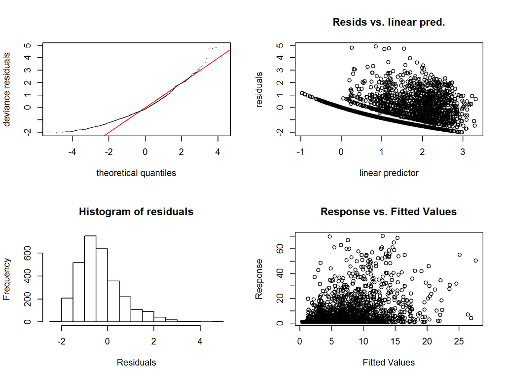

```
##
## Method: GCV   Optimizer: outer newton
## full convergence after 6 iterations.
## Gradient range [8.284852e-08,5.176092e-07]
## (score 1.05535 & scale 1.735585).
## Hessian positive definite, eigenvalue range [0.0002465521,0.0002868282].
## Model rank =  39 / 39
##
## Basis dimension (k) checking results. Low p-value (k-index<1) may
## indicate that k is too low, especially if edf is close to k'.
##
##                         k'   edf k-index p-value
## s(STARTLON,STARTLAT) 29.00 28.64    0.67  <2e-16 ***
## s(SALBOTM)            9.00  8.52    0.87     0.1
## ---
## Signif. codes:  0 '***' 0.001 '**' 0.01 '*' 0.05 '.' 0.1 ' ' 1
```

```r
### Fit a simple GAM with default k values

AIC_1 <- gam((cpe + 1) ~ s(STARTLON, STARTLAT) +
               s(SALBOTM),
             family = Gamma(link=log),
             data = sharpnose)

par(mfrow=c(2,2))
gam.check(AIC_1) ### both k-values seem like they could be increased especially Lat Lon
```

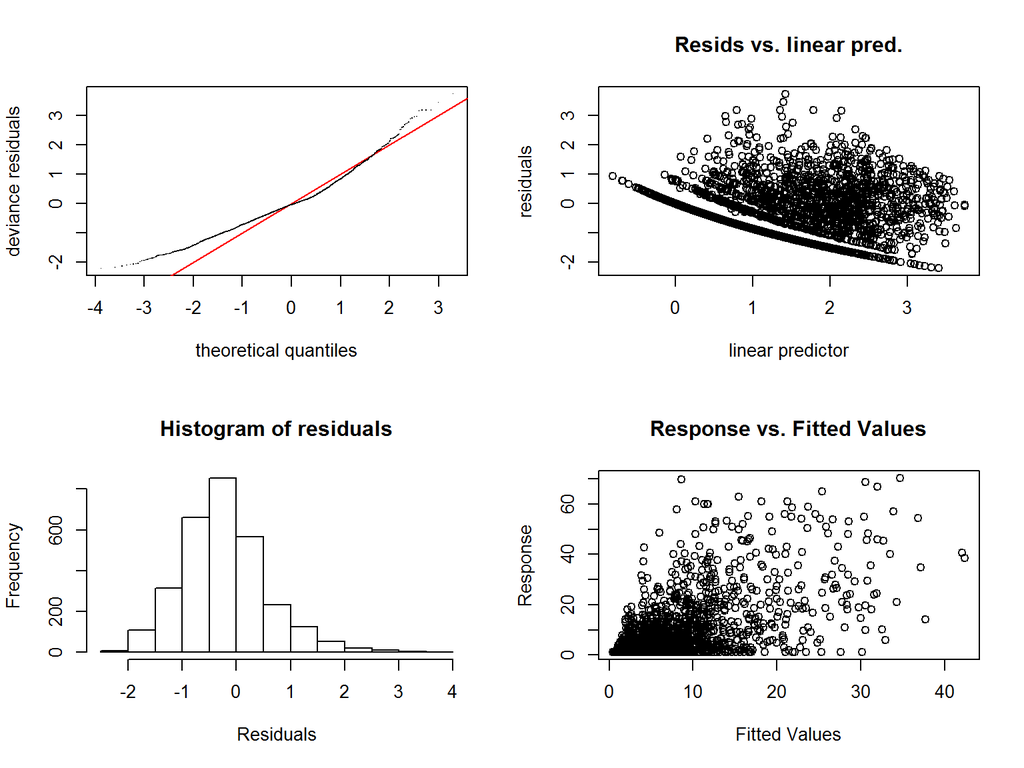

```
##
## Method: GCV   Optimizer: outer newton
## full convergence after 7 iterations.
## Gradient range [1.763982e-09,3.760868e-09]
## (score 0.7826942 & scale 0.9824923).
## Hessian positive definite, eigenvalue range [0.0002028491,0.008966574].
## Model rank =  259 / 259
##
## Basis dimension (k) checking results. Low p-value (k-index<1) may
## indicate that k is too low, especially if edf is close to k'.
##
##                         k'   edf k-index p-value
## s(STARTLON,STARTLAT) 199.0 171.6    0.88  <2e-16 ***
## s(SALBOTM)            59.0  35.1    0.92    0.36
## ---
## Signif. codes:  0 '***' 0.001 '**' 0.01 '*' 0.05 '.' 0.1 ' ' 1
```

```r
### Now fit gam with elevated k-value

AIC_2 <- gam((cpe + 1) ~ s(STARTLON, STARTLAT, k = 200) +
               s(SALBOTM,
                 k = 60),
             family = Gamma(link=log),
             data = sharpnose)

gam.check(AIC_2)
```

```r
AIC(AIC_1, AIC_2)
```

|  | df | AIC |
| --- | --- | --- |
| AIC_1 | 39.1636 | 14356.26 |
| AIC_2 | 208.6747 | 13289.86 |

```r
AIC_1$aic
```

```
## [1] 14356.26
```

```r
AIC_2$aic
```

```
## [1] 13289.86
```